#### Lucie Delay - MECI 2021/22 - Fiche 1 AMA - Cours de Thibaud Deguilhem Le choc de la pandémie a mis en lumière l’importance de la vulnérabilité pour la croissance et le développement d’un territoire : « *Les conséquences de la pandémie aggraveront les risques multidimensionnels existants et mettront à rude épreuve les capacités d’adaptation de ceux qui sont le moins à même d’y faire face* » (OCDE, 2020). Malgré de nombreux atouts, l’Argentine était, déjà avant la pandémie, particulièrement exposée à des chocs socio-politiques et économiques mettant à mal la résilience du pays et révélant sa vulnérabilité. La pandémie frappe alors une économie déjà à bout de souffle et renforce considérablement les difficultés, malgré des mesures d’urgence pour protéger les groupes les plus vulnérables. Pour l’OCDE (2020), il faut concentrer l’action sur la fragilité pour atténuer l’impact du COVID-19, et plus précisément valoriser le capital humain en investissant dans la santé, l’éducation et la protection sociale. Dans ce rapport nous allons déterminer comment mesurer la fragilité d’une province pour allouer des fonds à celles qui en ont le plus besoin. Les 2 profils qui sont visés par les programmes que l’UNICEF souhaite mettre en place en Argentine, sont les 2 provinces les plus vulnérables (pour le programme “Women empowerment”) et les 2 provinces les moins vulnérables (pour le programme “No-Poor”). De notre travail statistique exploratoire, Chaco et Formosa ressortent comme étant les 2 provinces à viser pour le programme “Women empowerment”, et Santa Cruz et Chubut pour le programme “No-Poor”. Dans un premier temps, nous définissons les critères d’un bon indicateur de vulnérabilité pour pouvoir faire un tri en connaissance de cause dans les variables de la base de données que nous utilisons : Argentina Socio-Economic Data by Province 2020. Ensuite, nous utilisons plusieurs outils de statistique exploratoire pour mettre en avant les ressemblances et les différences entre les provinces d’Argentine, dans le but d’aboutir à une typologie stable. La première méthode est celle de l’ACP (Analyse en Composantes Principales), qui nous fournit une échelle de mesure de la vulnérabilité à partir des variables retenues de la base de données. C’est sur les extrêmes de cette même échelle que nous cherchons les provinces qui nous intéressent. Pour cela, nous effectuons 2 partitionnements, un avec la méthode des K-means, l’autre avec la méthode de la CAH (Classification Ascendante Hiérarchique). Ces 2 partitionnements étant rigoureusement les mêmes, nous pouvons considérer nos résultats comme stables, valables et robustes. L’OCDE (2020) définit la vulnérabilité (ou la fragilité) comme « *la conjonction d’une exposition à des risques et d’une capacité insuffisante de l’État, d’un système ou d’une communauté à gérer, absorber ou atténuer ces risques. La fragilité peut avoir des conséquences dommageables comme la violence, la pauvreté, les inégalités, les déplacements, la dégradation de l’environnement ou la détérioration de la situation politique.* » Plus simplement, la vulnérabilité est le risque d’être affecté par un choc, endogène ou exogène. Ci-dessous est un schéma qui illustre la définition de la vulnérabilité de l’OCDE, complétée des apports de l’article de Guillaumont et al. (2020). L’OCDE mesure la fragilité des pays sur une échelle d’intensité de 1 à 6, sur laquelle se placent 6 indicateurs de vulnérabilité qui recouvrent 6 formes de fragilités : économique, environnementale, politique, sécuritaire, sociale et de capital humain. Il n’existe pas de vulnérabilité sanitaire car les formes de vulnérabilité renvoient aux canaux de transmission nationaux des chocs et leurs impacts, et non pas à l’origine des chocs eux-mêmes (pouvant être sanitaires dans ce cadre). Pour exprimer ces indicateurs de fragilité l’OCDE utilise des méthodes statistiques de classification agrégeant un grand nombre de variables quantitatives, structurelles ou non (Guillaumont et al., 2020, 45). Pour chaque forme de vulnérabilité, on peut distinguer la vulnérabilité structurelle qui résulte de facteurs de long terme, de la vulnérabilité découlant des choix politiques, qui est plus éphémère. Pour déterminer l’allocation d’une aide, un indicateur de fragilité ne doit refléter que la vulnérabilité structurelle: les facteurs exogènes, persistants et résultants d’évènements complètement indépendants de la volonté des pays. Idéalement, un indicateur de vulnérabilité doit également recouvrir les différentes formes de vulnérabilité, être relativement simple et transparent même s’il est composite, éviter les redondances et enfin utiliser des mesures reconnues internationalement pour renforcer sa légitimité. Pour Guillaumont (2020, 55), il est nécessaire de prendre en compte des indicateurs de vulnérabilité économique structurelle pour mesurer la vulnérabilité générale. La vulnérabilité économique structurelle recouvre à la fois l’exposition aux chocs et leur ampleur. Pour mesurer l’exposition aux chocs il retient 4 composantes : la taille de la population, l’éloignement des marchés mondiaux, la structure de l’économie (part des secteurs agriculture sylviculture et pêche, concentration des exportations de biens), et le développement des infrastructures. Pour mesurer l’ampleur des chocs il retient l’instabilité de la production agricole, les victimes de désastres naturels et l’instabilité des exportations de biens et services. Par ailleurs, la vulnérabilité climatique tient compte de la hausse du niveau de la mer et de la tendance à l’accroissement des températures, des chocs de précipitations et d’intensité des cyclones. La vulnérabilité sociétale, elle, se mesure par les conflits armés internes, la criminalité, le terrorisme, la violence politique et les conflits de voisinage. Guillaumont (2020, 49) conseille également d’intégrer des indicateurs généraux de besoin et de faible capacité/résilience à la mesure de la vulnérabilité. Si le PIB/habitant et la population (qui représente un handicap si elle est trop faible et réduit la résilience si elle est jeune) sont des indicateurs de besoin reconnus et nécessaires, ils sont insuffisants car ils n’incluent pas le niveau de capital humain, « dont le faible niveau reflète une dimension de la pauvreté différente du revenu par tête », et qui réduit également la résilience et révèle un manque de capacité de développement. L’indice de capital humain préconisé par Guillaumont (2020, 53) regroupe 3 dimensions : l’éducation (taux de scolarisation dans l’enseignement supérieur, taux d’alphabétisation des adultes), la santé (prévalence de la sous-alimentation, taux de mortalité chez les enfants de moins de 5 ans) et la pression démographique (part des 0-19 ans dans la population, nombre de réfugiés). Il nous semble tout d’abord nécessaire de préciser que vulnérabilité et pauvreté ne sont pas la même chose. Certes, la pauvreté est concentrée dans les contextes fragiles, qui abritent 76% d’individus en situation d’extrême pauvreté; mais être pauvre n’implique pas nécessairement une situation de vulnérabilité et vice-versa. En 2020, 43% de la population des contextes fragiles vivent en milieu urbain, contre 54% de la population des contextes non fragiles. Cependant les contextes fragiles urbains sont de plus en plus nombreux et devraient abriter 59% de la population des contextes fragiles d’ici 2050 (OCDE, 2020, 19). De plus, 1/3 des enfants dans le monde vivent dans des contextes vulnérables, soit 38% de la population totale des contextes fragiles. Les provinces argentines présentent des inégalités de développement marquées. Brasseul et al.(2022) opposent le nord en développement (Formosa, Chaco, Corrientes, Missiones, Santiago del Estero) au sud développé (Buenos Aires, Santa Fe, Córdoba, Mendoza), en passant par une zone intermédiaire (Salta, Tucumán, Entre Rios, San Juan et San Luís) et en allant jusqu’aux provinces de faible densité en Patagonie. Pour Brasseul et al.(2022), une nouvelle dynamique se met en place : les différences s’accentuent à l’intérieur des provinces et des villes, avec des poches de pauvreté dans certains quartiers des villes favorisées et des poches d’activités minières et touristiques dans les provinces les moins développées. Brasseul, Jacques, Romain GAIGNARD, Roland LABARRE, Luis MIOTTI, Carlos QUENAN, Jérémy RUBENSTEIN, Sébastien VELUT, « ARGENTINE », *Encyclopædia Universalis* [en ligne], consulté le 10 mars 2022. Guillaumont, Patrick. « La vulnérabilité macroéconomique des pays à faible revenu et les réponses de l’aide », *Revue d’économie du développement*, vol. 14, no. 4, 2006, pp. 21-77. Guillaumont, Patrick, Sylviane Guillaumont-Jeanneney, et Laurent Wagner. *Mesurer les vulnérabilités pour allouer l’aide au développement, en particulier en Afrique.* Clermont-Ferrand : FERDI, 2020. OCDE. « Etats de fragilité 2020 ». Paris : Editions OCDE, 2020. Nous travaillons sur les données socio-économiques par province collectées en 2020. Ci-dessous se trouve un tableau récapitulant les variables de la base de donnée et leur unité de mesure. Nous ajoutons dès maintenant la variable GDP/cap (PIB/hab) à nos données, variable qui est le principal indicateur général de besoin selon P.Guillaumont. Variables Unités GDP $ illiteracy Taux d’analphabétisme poverty Taux de pauvreté (% population sous le seuil de pauvreté) deficient_infra Taux d’infrastructure school_dropout Taux de décrochage scolaire no_healthcare % population active sans système de santé birth_mortal Taux de mortalité à la naissance pop Population totale movie_theatres_per_cap Cinémas / habitant doctors_per-cap Docteurs /habitant GDP/cap PIB/habitant en $ Voici ensuite les résumés statistiques des variables. variable n mean min max birth_mortal 22 5 1 16 deficient_infra 22 13 4 31 doctors_per_cap 22 0 0 0 gdp 22 30557028 3807057 292689868 gdppop 22 18 7 43 illiteracy 22 3 1 8 movie_theatres_per_cap 22 0 0 0 no_healthcare 22 51 29 66 pop 22 1686352 273964 15625084 poverty 22 10 3 17 school_dropout 22 2 0 4 Les écarts importants entre minimum et maximum, quelques soient les variables, nous indiquent de fortes disparités entre les provinces. Nous voyons également que le nombre de cinémas et de docteurs par habitant est trop faible pour être représenté dans le résumé statistique. Pour chaque variable, 22 provinces sont représentées, nous n’avons donc pas de valeur manquante dans notre base de donnée. Cependant, il existe 23 et non pas 22 provinces en Argentine : la base de donnée ne prend pas en compte une province (Terre de feu, Antartique et Îles de l’Atlantique Sud). Comme celle-ni n’est que très peu peuplée, ce n’est pas de grande importance. Voici ci-dessous la carte des 23 provinces de l’Argentine. Nous allons utiliser plusieurs méthodes de statistique exploratoire dans le but d’établir une typologie des provinces d’Argentine, sur la base de notre base de données. La grande limite des outils de statistique exploratoire est que leur interprétation dépend énormément des choix de l’auteur : indépendamment, ces méthodes sont peu robustes. Mais leur force est lorsqu’elles produisent ensemble le même résultat, dont la robustesse et la stabilité sont ainsi renforcée. Nous utilisons l’ACP, les k-means et la CAH qui sont les 3 méthodes les plus couramment utilisées, mais il faut savoir qu’elles sont beaucoup plus nombreuses (ex: random forest). Nous estimons toutefois que ces 3 méthodes suffisent à établir une robustesse des résultats. Avant de commencer, nous choississons les variables de la base de données à retenir. Ce choix détermine ensuite les variables qui participent à la construction des axes des méthodes de classification, et donc à la construction de l’indicateur de vulnérabilité. Nous enlevons GDP et POP car nous avons créé la variable GDP/cap qui est le principal indicateur général de besoin selon P.Guillaumont. Il devient inutile de garder GDP, et même si nous aurions pu garder POP, nous l’enlevons car cette variable ne mesure pas la pression démographique (part de population jeune). Cette variable aurait donc pu nous induire en erreur, en particulier pour le cas de Buenos Aires. Egalement, nous enlevons la variable movie_theatres_per_cap car cette variable ne mesure pas la vulnérabilité et parait peu pertinente. De même, nous enlevons doctors_per_cap et school_dropout qui sont redondantes avec no_healthcare et illiteracy. Selon l’analyse de Guillaumont, nous nous retrouvons alors avec des variables de fragilité économique structurelle (ici les infrastructures uniquement) et de capital humain (ici santé et éducation uniquement). La prépondérance de variables de capital humain est pertinente compte tenu des recommandations de l’OCDE (2020) pour atténuer l’impact du Covid-19. L’ACP (Analyse en Composantes Principales) va nous donner une échelle de mesure de la vulnérabilité à partir des variables de notre base de données, en ne gardant que le plus important de l’information statistique. Cela nous permettra de distinguer les provinces argentines en groupes similaires, et donc de voir lesquelles sont les plus vulnérables ou pas. Les conditions de l’ACP sont respectées : nous avons plus de 4 variables, qui sont continues. Nous n’avons que 22 individus mais cela était imposé par notre sujet. Toutefois, l’idéal aurait été d’en avoir au moins 100. Nous avons toujours plus de 10 observations par variable. Les liaisons préalables entre variables (bivariées) sont suffisamment diversifiées et importantes pour que l’ACP soit pertinente. Nous avons vérifié cela avec la matrice des corrélations et le test de Barlett, que vous pouvez consulter en cliquant sur “details”. illiteracy poverty deficient_infra no_healthcare birth_mortal gdppop illiteracy 1.00 0.64 0.58 0.79 0.34 -0.65 poverty 0.64 1.00 0.50 0.69 0.47 -0.58 deficient_infra 0.58 0.50 1.00 0.63 0.38 -0.38 no_healthcare 0.79 0.69 0.63 1.00 0.35 -0.75 birth_mortal 0.34 0.47 0.38 0.35 1.00 -0.34 gdppop -0.65 -0.58 -0.38 -0.75 -0.34 1.00 Ci-dessous se trouve le diagramme en barres des valeurs propres (ou des inerties), associées à chaque axe. Les 2 premiers axes de l’analyse expriment 75% de l’inertie totale du jeu de données ; cela signifie que 75% de la variabilité totale du nuage des individus (ou des variables) est représentée dans ce plan. Nous retenons donc 2 axes. Attention, le premier facteur est prépondérant : il explique à lui seul 62% de la variabilité totale des données. Dans un tel cas, la variabilité liée aux autres composantes peut ne pas avoir de sens. Toutes nos variables, sauf deficient_infra, sont bien représentées sur les 2 axes que nous avons sélectionnés (cf détails). L’axe 1 est définit par les variables suivantes : no_healthcare, illiteracy, poverty, gdppop (cf details). L’axe 2 est définit par la variable birth_mortal (cf details). Aucun des 2 axes ne prend en compte deficient_infra. Peu de provinces contribuent à ces 2 dimensions: nous ne pourrons interpréter uniquement les positions de Formosa, Chaco, Santa Cruz, Santiago del Estero, Chubut, Corrientes; soit 6 provinces sur 22 (cf details). Toutefois comme ce sont ces provinces qui se situent aux extrêmes, cela n’est pas génant, sauf s’il s’avère qu’une seule variable prend trop d’importance dans la définition de l’indicateur de vulnérabilité. On voit sur le cercle des représentations et des contributions que la variable deficient_infra est à la fois moins bien représentée, et qu’elle contribue moins aux dimensions (cf details). FALSE [1] 62.51736 75.93129 86.24017 92.59348 97.35822 100.00000 Avant d’analyser les résultats de l’ACP, il est important de rappeler que toutes les provinces ne se placent pas sur les 2 axes qui nous avons retenu. D’autres appartiennent à un troisième plan, qui sont assez nombreuses et situées au centre du graphique (cf details). Nous nous garderons d’interpréter la position de ces provinces. Cependant, puisque le but de ce rapport est uniquement de répérer les extrêmes, cela ne pose pas problème. Voici ci-dessous le bilan de l’ACP. L’axe 1 (horizontal) traduit une opposition entre le PIB/hab (à gauche) et les variables no_healthcare, illiteracy, poverty (à droite). L’axe 2 (vertical) traduit une forte mortalité infantile (en haut), ou une faible mortalité infantile (en bas). Chaco et Formosa sont caractérisées par : - de fortes valeurs pour les variables deficient_infra, poverty, no_healthcare et illiteracy. - de faibles valeurs pour la variable gdppop Corrientes, Misiones et Santiago del Estero sont caractérisées par : - de fortes valeurs pour les variables poverty, illiteracy et no_healthcare - de faibles valeurs pour la variable gdppop Chubut, La Pampa, La Rioja, Rio-Negro et Santa Cruz sont caractérisées par: - de fortes valeurs pour la variable gdppop - de faibles valeurs pour les variables poverty, no_healthcare, illiteracy et deficient_infra A vue d’oeil, les 2 provinces les plus vulnérables seraient Formosa et Chaco, et les 2 provinces les moins vulnérables seraient Santa Cruz et Chubut. Nous allons maintenant déterminer cela statistiquement, avec la méthode des K-means puis celle de la classification ascendante hiérarchique. Avec l’algorithme des K-means, nous allons établir une typologie se basant sur les axes que nous avons déterminés avec l’ACP. L’inconvénient de cette méthode est que nous avons du nous-même définir un nombre de groupes, ce qui représente un problème épistémologique. C’est pourquoi nous allons ensuite compléter la méthode des k-means avec celle de la classification ascendante hiérarchique, qui permet de ne pas pré-spécifier le nombre de groupes. La matrice des distances confirme ce que nous avons vu sur le graphique de l’ACP : les oppositions sont particulièrement marquées entre Chaco et Formosa d’une part et Santa Cruz et Chubut d’autre part. Maintenant, nous allons déterminer combien de groupes nous allons spécifier à l’algorithme k-means, pour qu’il puisse nous effectuer une typologie des provinces plus ou moins vulnérables d’Argentine. Nous voyons dans “details” que le choix de 5 groupes doit être écarté car dans ce cas, 2 d’entre eux se superposent. Comme nous recherchons des groupes les plus restreints possibles aux extrêmes (idéalement 2), le choix de 4 groupes parait plus pertinent. Nous pouvons vérifier que 4 est est le nombre de cluster idéal avec plusieurs méthodes. Celle du coude d’effondrement (cf details) montre bien une rupture dans la linéarité de la variance intra-groupe après k=4. Selon l’indice de la silouette, 5 serait un meilleur choix. Mais comme les 2 groupes extrêmes sont les mêmes avec 4 ou 5 groupes, cela n’impacte pas notre analyse. Voici donc la partition que nous allons retenir avec les k-means: Nous pouvons caractériser ces clusters selon leurs moyennes par variable, qui ont été standardisées (cf details). Clusters Moyenne.illiteracy Moyenne.poverty Moyenne.deficient_infra Moyenne.no_healthcare Moyenne.birth_mortal Moyenne.gdppop 1 -0.97 -0.37 -0.52 -1.26 -0.51 2.03 2 -0.38 -0.61 -0.37 -0.36 -0.21 0.01 3 0.88 0.99 0.26 0.97 0.02 -0.86 4 1.53 1.73 2.36 1.62 1.96 -0.97 Le groupe plutôt à gauche est caractérisé par des variables neutres, proches de 0. On remarque que c’est au sein de ce groupe que la pauvreté est la moins présente. Le groupe tout à droite est caractérisé par des variables extrêmement fortes (illiteracy, poverty, deficient_infra, no_healthcare, birth_mortal), sauf pour le gpd/pop qui est extrêmement faible. Le groupe plutôt à droite est caractérisé par une très forte illiteracy, poverty et no_healthcare (dans une moindre mesure que le groupe 2), un très faible gdp/pop (dans une moindre mesure que le groupe 2), et un deficient_infra et birth_mortal neutres. Le groupe tout à gauche est caractérisé par un gdp/pop extrêmement fort et c’est lui qui a les plus faibles valeurs pour les autres variables (sauf pour poverty, qui reste faible). Voici ci-dessous les membres des 4 clusters (cf details): x Buenos Aires 2 Catamarca 2 Cordoba 2 Corrientes 3 Chaco 4 Chubut 1 Entre-Rios 2 Formosa 4 Jujuy 3 La Pampa 2 La Rioja 2 Mendoza 2 Misiones 3 Neuquen 1 Rio-Negro 2 Salta 3 San Juan 2 San Luis 2 Santa Cruz 1 Santa Fe 2 Santiago del Estero 3 Tucuman 2 Les groupes dont la variance intra-groupe est la plus élevée sont les groupes du milieu, qui nous interessent peu. Les groupes des extrêmes qui nous intéressent ont une variance intra-groupe faible, ils sont donc fiables pour continuer notre analyse. Clusters Variance_intra_groupe 1 3.03 2 22.38 3 10.07 4 4.51 S’il est clair que les 2 provinces les plus vulnérables sont Chaco et Formosa, quelles sont les 2 les moins vulnérables parmi Santa Cruz, Chubut et Neuquen? Ci-dessous se trouvent les variables pour ces 3 provinces. illiteracy poverty deficient_infra no_healthcare birth_mortal gdppop Santa Cruz 0.79 8.02 7.41 29.23 3.3 42.57 Neuquen 1.94 9.46 11.27 48.74 3.3 40.93 Chubut 1.55 8.05 8.04 39.55 3.0 34.86 La plus vulnérable des 3 est Neuquen car elle a les valeurs maximales pour toutes les variables, sauf pour la variable gdppop pour laquelle Chubut est la province la moins bien dotée. Comme nous donnons le même poids à chacune des variables, nous retenons Santa Cruz et Chubut comme étant les 2 provinces les moins vulnérables. Nous allons vérifier la robustesse de ce résultat en utilisant une autre méthode de statistique exploratoire pour répondre à la même question : la CAH. Nous choisissons comme troisième méthode le clustering agglomératif ascendant car c’est la plus courante, mais surtout c’est la méthode de clustering la plus consistante en termes de rassemblement. En effet, en considérant d’abord les individus comme des clusters, on joint la méthode de la distance à celle du rassemblement des clusters, ce qui implique une double contrainte. Nous repartons de la matrice de distance établie pour les k-means. Mais alors que les k-means s’arrêtaient à la définition de groupes caractérisés par une faible inertie intra-groupe et une forte inertie inter-groupe, la CAH va ensuite mesurer la ressemblance / dissemblance entre les différents groupes. Pour cela, il existe plusieurs méthodes de mesure de la distance que nous allons comparer pour déterminer la plus adaptée à notre question. Nous voyons ci-dessous que c’est la méthode de Ward qui maximise la variance inter-groupe, comme c’est souvent le cas. En cliquant sur “details”, vous avez la visualisation des dendogrammes pour toutes les méthodes de mesure de la distance. Méthode Coefficient_agglomération average 0.7071084 single 0.5426464 complete 0.7847117 ward 0.8546184 Nous pouvons vérifier la stabilité des résultats selon les méthodes, pour asseoir le fait que nous n’avons pas fait les choix qui arrangeaient simplement notre analyse. Nous voyons que, qu’on choisisse la méthode de Ward et ou du lien complet, les résultats sont quasiment les mêmes et ne sont pas sensibles à la méthode utilisée (cf details). L’entanglement est proche de 1 qui indique une similitude parfaite. On peut déjà avec la visualisation du dendrogramme de Ward, imaginer des partitionnements en 2 et 4 groupes (aux noeuds les plus hauts, qui ont le plus grand intervalle en terme de variance). Si la partition en 2 groupes maximise les différences entre les groupes, nous estimons que nous perdons beaucoup d’information. Pour équilibrer ces 2 critères, nous nous dirigeons donc vers une partition en 4 groupes. Voici ci-dessous une idée rapide du partitionnement du dendrogramme en 4 groupes et le tableau du nombre de provinces par cluster. sub_grp Freq 1 12 2 5 3 2 4 3 Nous pouvons également justifier ce choix de k=4 statistiquement, comme pour les k-means (cf “details”). La rupture de pente de la variance intra-groupe se situe bien à k=4. De même la silhouette était maximisée pour 2, mais nous estimons que trop d’information est perdue avec k=2 et qu’une partition en 2 ne suffit pas pour que les provinces les +/- vulnérables se détachent des autres. De même pour la silhouette, une fois 2 éliminé, 4 et 5 se justifient, mais nous éliminons 5 car l’information apportée en plus n’est pas utile à notre question (le groupe supplémentaire ne se situe pas aux extrêmes). Avec le gap statistic nous voyons que 2 et 4 se valent, même si la variablité est plus importante avec k=4. K=5 est moins pertinent selon cette méthode. Retenir k=4, aux vues des dendrogrammes et des indicateurs statistiques, est pertinent. FALSE Clustering Gap statistic ["clusGap"] from call: FALSE clusGap(x = ag6s, FUNcluster = hcut, K.max = 10, B = 50, nstart = 25, K.min = 2) FALSE B=50 simulated reference sets, k = 1..10; spaceH0="scaledPCA" FALSE --> Number of clusters (method 'firstmax'): 1 FALSE logW E.logW gap SE.sim FALSE [1,] 2.808467 2.963110 0.1546434 0.05655465 FALSE [2,] 2.495451 2.640105 0.1446547 0.05447963 FALSE [3,] 2.367784 2.475192 0.1074088 0.05827778 FALSE [4,] 2.202717 2.344215 0.1414981 0.05926932 FALSE [5,] 2.093177 2.222915 0.1297373 0.05805174 FALSE [6,] 1.980068 2.104426 0.1243576 0.05722304 FALSE [7,] 1.845986 1.989402 0.1434164 0.05599682 FALSE [8,] 1.719807 1.873835 0.1540279 0.05625819 FALSE [9,] 1.579941 1.758592 0.1786513 0.05961902 FALSE [10,] 1.448188 1.637786 0.1895982 0.06383592 Ci-dessous la visualisation de la CAH (avec k=4) sur les axes déterminés par l’ACP, suivie de la visualisation des k-means (avec k=4). Nous voyons que les groupes sont rigoureusement les mêmes, ce qui implique que nos résultats sont stables et robustes. Comme la partition est la même, nous pouvons reprendre les résultats précédents concernant le groupe des provinces les moins vulnérables: seules Santa Cruz et Chubut sont retenues. Voici donc ci-dessous les résultats visuels de notre partition: Nous pouvons regretter que la base de donnée disponible n’ait permis qu’une image tronquée des formes de vulnérabilité auxquelles est confrontée l’Argentine. Les vulnérabilités climatique ou sociétale ne sont absolument pas prises en compte, ce qui peut particulièrement poser problème si l’on utilise cette mesure de la vulnérabilité dans les pays Africains. On peut également regretter que les axes de l’ACP ne prennent que peu en compte les infrastructures et donnent un certain avantage aux provinces peu peuplées, qui sont plus facilement non vulnérables dans la mesure où leur GDP/cap est tiré par une faible population. Cet avantage était moins important en gardant les variables movie_theatres_per_cap et doctors_per_cap, mais les résultats restaient les mêmes. Nous pouvons donc regretter l’absence de variable permettant de véritablement contrebalancer le GDP/cap pour mesurer la non-vulnérabilité. En faisant nos choix de variables retenues, que ce soit selon l’ACP, selon les k-means ou selon la CAH, Chaco et Formosa sont les provinces les plus vulnérables d’Argentine, et Santa Cruz et Chubut sont les provinces les moins vulnérables d’Argentine. Ce résultat est robuste de part sa stabilité selon les méthodes utilisées. # Les Packages #install.packages("Factoshiny") #install.packages("cluster") #install.packages("kableExtra") library(kableExtra) library(knitr) library(Factoshiny) library(ggplot2) library(corrplot) library(psych) library(prettydoc) library(FactoMineR) library(factoextra) library(gridExtra) library(cluster) library(rstatix) library(tinytex) library (gridExtra) library (cluster) library(purrr) #Charger les données ag <- read.table(file = "Data/argentina.csv", # nom du fichier sep = ",", # séparateur header = TRUE, # variables en première ligne row.names = 1, # individus en première colonne check.names = F) ##Créer la variable GDP/POP dans le data frame ag ag$gdppop<-(ag$gdp/ag$pop) #Description des données # Colonne 1 vec1<-c("GDP", "illiteracy","poverty","deficient_infra","school_dropout","no_healthcare","birth_mortal","pop", "movie_theatres_per_cap","doctors_per-cap","GDP/cap") # Colonne 2 vec2<-c("$","Taux d'analphabétisme","Taux de pauvreté (% population sous le seuil de pauvreté)","Taux d'infrastructure", "Taux de décrochage scolaire","% population active sans système de santé ","Taux de mortalité à la naissance", "Population totale","Cinémas / habitant", "Docteurs /habitant","PIB/habitant en $") # Data Frame df<-data.frame(Variables=vec1, Unités = vec2) # Kable kable(df, digits = 0) %>% kable_classic_2() %>% kable_styling(font_size = 15,) #Statistiques des variables # Data frame statF <-get_summary_stats(ag, show = c("mean","min", "max"), ) # Kable kable(statF, digits = 0) %>% kable_classic_2() %>% kable_styling(font_size = 15,) #Préparation des données pour faire des comparaisons faciles ## Enlever les variables GDP (1) et POP (8) ag9<-ag[,c(2,3,4,5,6,7,9,10,11)] ##centrer-réduire ag2 ag9s<-scale(ag9) #Autres possibilités pour comparer ## Enlever les variables GDP (1) et POP (8) et CINE (9) ag8<-ag[,c(2,3,4,5,6,7,10,11)] ag8s<-scale(ag8) ## Enlever les variables GDP (1) et POP (8) et CINE (9) et SCHDROP (5) ag7<-ag[,c(2,3,4,6,7,10,11)] ag7s<-scale(ag7) ## ## Enlever les variables GDP (1) et POP (8) et CINE (9) et SCHDROP (5) et DOC (10) ag6<-ag[,c(2,3,4,6,7,11)] ag6s<-scale(ag6) #Matrice des corrélations ##Tableau mc<-cor(ag6s) kable(mc, digits = 2) %>% kable_classic_2() %>% kable_styling(font_size = 15,) ##Plot corrplot(mc, #Tableau des corrélations method = "square", #moyen d'affichage des corrélations type = "upper", #la partie du tableau qui s'affiche pch.cex = 2) #la taille des chiffres #Test de barlett bar.test<-cortest.bartlett(mc, n=nrow(ag6)) # Pourcentage d'inertie associée à chaque dimmension de l'ACP res.pca2= PCA(ag6s,graph=F) fviz_eig(res.pca2) #Le positionnement des variables sur les axes sélectionnés fviz_cos2(res.pca2,choice="var",axes = 1:2) #Composition de l'axe 1 fviz_contrib(res.pca2, choice = "var", axes = 1) #Composition de l'axe 2 fviz_contrib(res.pca2, choice = "var", axes = 2) #La contribution des individus fviz_contrib(res.pca2 , choice = "ind", axes = 1:2) #Cercle des représentations des variables cumsum(eigen(cor(ag6s))$values)/sum(eigen(cor(ag6s))$values )*100 fviz_pca_var(res.pca2 , col.var = "cos2") #contributions fviz_pca_var(res.pca2 , col.var = "contrib") #graphique des individus fviz_pca_ind(res.pca2, col.ind = "cos2", pointsize = "cos2", pointshape = 19, repel = TRUE) # synthèse du graphique des variables et des individus var <- get_pca_var(res.pca2) res.km2 <- kmeans(var$coord, centers = 2, nstart = 25) grp2 <- as.factor(res.km2$cluster) fviz_pca_biplot( res.pca2, repel = TRUE, pointsize = "cos2", col.var = grp2) # matrice des distances euclidiennes distanceE<-get_dist(ag6s) fviz_dist(distanceE, lab_size = "5", #taille des étiquettes plus petite gradient = list(low="grey",mid="white",high="red") # Changer les couleurs du dégradé ) #Comparaisons visuelles km2<-kmeans(ag6s,centers=2,nstart = 25) km3<-kmeans(ag6s,centers=3,nstart = 25) km4<-kmeans(ag6s,centers=4,nstart = 25) km5<-kmeans(ag6s,centers=5,nstart = 25) p1 <- fviz_cluster(km2, geom="point",data=ag6s)+ ggtitle("k=2") p2 <- fviz_cluster(km3, geom="point",data=ag6s)+ ggtitle("k=3") p3 <- fviz_cluster(km4, geom="point",data=ag6s)+ ggtitle("k=4") p4 <- fviz_cluster(km5, geom="point", data=ag6s)+ ggtitle("k=5") grid.arrange(p1,p2,p3,p4, nrow=2) #méthode coude fviz_nbclust(ag6s,kmeans,method="wss")+ theme_minimal() #silhouette fviz_nbclust(ag6s,kmeans,method="silhouette")+ theme_minimal() # Visualisation km4f<-kmeans(ag6s,centers=4,nstart = 25) fviz_cluster(km4f, data = ag6s, xlab = "Gdppop (à gauche), no_healthcare, illiteracy, poverty (à droite)", ylab = "Mortalité à la naissance", main = "Les groupes de provinces") + theme_minimal() #Statistiques des clusters mean<-km4$centers clusters<-c("1","2","3","4") tm<-data.frame(Clusters=clusters, Moyenne = mean) kable(tm, digits = 2) %>% kable_classic_2() %>% kable_styling(font_size = 15,) # Membres clusters membres<-km4$cluster kable(membres, digits = 2) %>% kable_classic_2() %>% kable_styling(font_size = 15,) #Tableau variance intra-groupe variances_intra_groupes<-km4$withinss tc<-data.frame(Clusters=clusters, Variance_intra_groupe = variances_intra_groupes) kable(tc, digits = 2) %>% kable_classic_2() %>% kable_styling(font_size = 15,) # stats sur cluster le moins vulnérable riches<-ag6[order(ag6$gdppop,decreasing = T), # Trier par la variable LG en ordre décroissant ] # on garde toutes les variables # Data.frame du top 3 top3riches<- head(riches,3) kable(top3riches, digits = 2) %>% kable_classic_2() %>% kable_styling(font_size = 15,) #Comparer les méthodes de linkage (coef agglomération) # fonction AGNES hc1<-agnes(distanceE,method="average") hc2<-agnes(distanceE,method="single") hc3<-agnes(distanceE,method="complete") hc4<-agnes(distanceE,method="ward") #les ac #hc1$ac #hc2$ac #hc3$ac #hc4$ac # tableau des résultats vecm <-c("average","single","complete","ward") vecac<-c("0.7071084","0.5426464","0.7847117","0.8546184") dac<-data.frame(Méthode=vecm, Coefficient_agglomération = vecac) # Kable kable(dac, digits = 2) %>% kable_classic_2() %>% kable_styling(font_size = 15,) #les dendro dd1<-pltree(hc1,cex=0.6,hang=-1,main="Dendrogramme average linkage") dd2<-pltree(hc2,cex=0.6,hang=-1,main="Dendrogramme simple linkage") dd3<-pltree(hc3,cex=0.6,hang=-1,main="Dendrogramme complete linkage") dd4<-pltree(hc4,cex=0.6,hang=-1,main="Dendrogramme ward linkage") #2 HC avec deux méthodes hcA<-hclust(distanceE,method="complete") hcB<-hclust(distanceE,method="ward.D2") #Créer 2 dendrogrammes dend1<-as.dendrogram(hcA) dend2<-as.dendrogram(hcB) #complete à gauche, Ward à droite #inclure coef et modifier visualisation dend_list<-dendlist(dend1,dend2) hi<-1-(entanglement(dend_list)) tanglegram(dend1,dend2,highlight_distinct_edges=F, common_subtrees_color_lines=T, common_subtrees_color_branches=T, main="Alignement des dengrogrammes (complet/Ward)", sub= paste("entanglement=",round((hi),2))) #Visualisation des 4 groupes ## HC avec la méthode de Ward (linkage + D2 = euclidienne) hc5<-hclust(distanceE,method="ward.D2") ## Couper l'arbre en 4 groupes sub_grp<-cutree(hc5, k=4) #Ajouter la variable "cluster" à la base de donnée ag6s ag6c<-ag6%>% mutate(cluster=sub_grp) plot(hc5,cex=0.6) rect.hclust(hc5,k=4,border=2:5) # nb d'observations dans chaque cluster (refaire beau tableau) nboc<-table(sub_grp) kable(nboc, digits = 2,main="Nombre d'observations par cluster") %>% kable_classic_2() %>% kable_styling(font_size = 15) #justification partitionnement en 4 (pareil que k-means) #Elbow fviz_nbclust(ag6s,FUN=hcut,method="wss")+ theme_minimal() #silhouette fviz_nbclust(ag6s,FUN=hcut,method="silhouette")+ theme_minimal() #Gap stat gap_stat2<-clusGap(ag6s,FUN=hcut,nstart=25,K.max=10, K.min=2,B=50) print(gap_stat2,method="firstmax") fviz_gap_stat(gap_stat2)+ theme_minimal() #Visualiser CAH k=4 sur un plan à 2 diensions (ACP comm k-means) fviz_cluster(list(data=ag6s,cluster=sub_grp), xlab = "Dim 1 (62,5%) : Gdppop (à gauche), no_healthcare, illiteracy, poverty (à droite)", ylab = "Dim 2 (13,4%) : Mortalité à la naissance", main = "Les groupes de provinces (CAH)" )+ theme_minimal() #Rappel des k-means pour comparer facilement km4f<-kmeans(ag6s,centers=4,nstart = 25) fviz_cluster(km4f, data = ag6s, xlab = "Dim 1 (62,5%) : Gdppop (à gauche), no_healthcare, illiteracy, poverty (à droite)", ylab = "Dim 2 (13,4%) : Mortalité à la naissance", main = "Les groupes de provinces (k-means)") + theme_minimal() #Dengro horizontal en couleurs fviz_dend(hc5,k=4,cex=0.55,horiz=T,rect=T,rect_border = "jco",rect_fill = TRUE,xlab = "Nombre de provinces",ylab="Hauteur du noeud", main = "Dendogramme de la partition en 4 groupes avec la CAH")+ theme_minimal() #dendro circulaire fviz_dend(hc5,k=4, cex=0.6,k_colors = "jco", type = "circular",lwd=F, ylab = "", xlab = "", main = "Dendogramme circulaire de la partition en 4 groupes avec la CAH")+ theme_minimal()

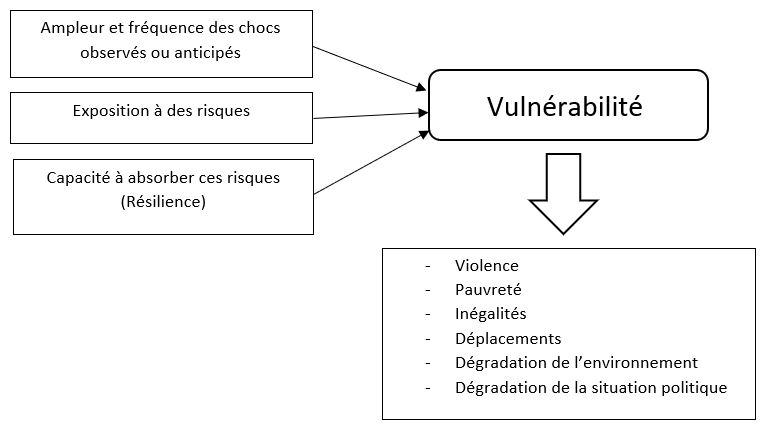

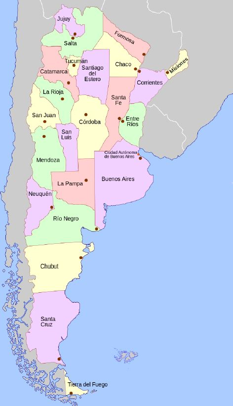

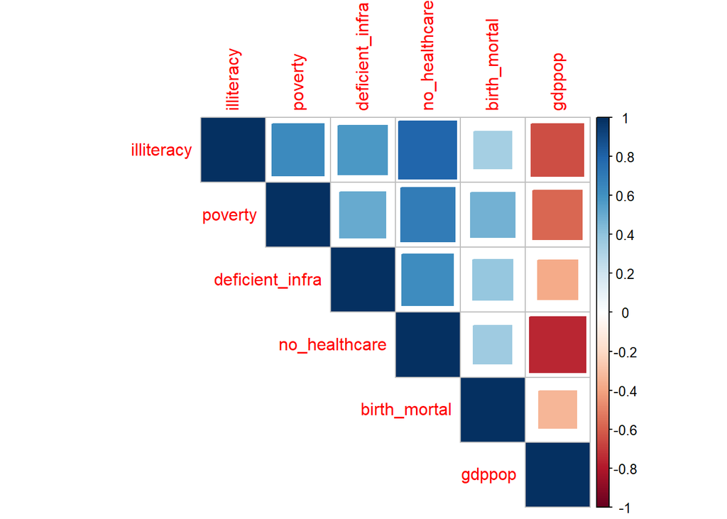

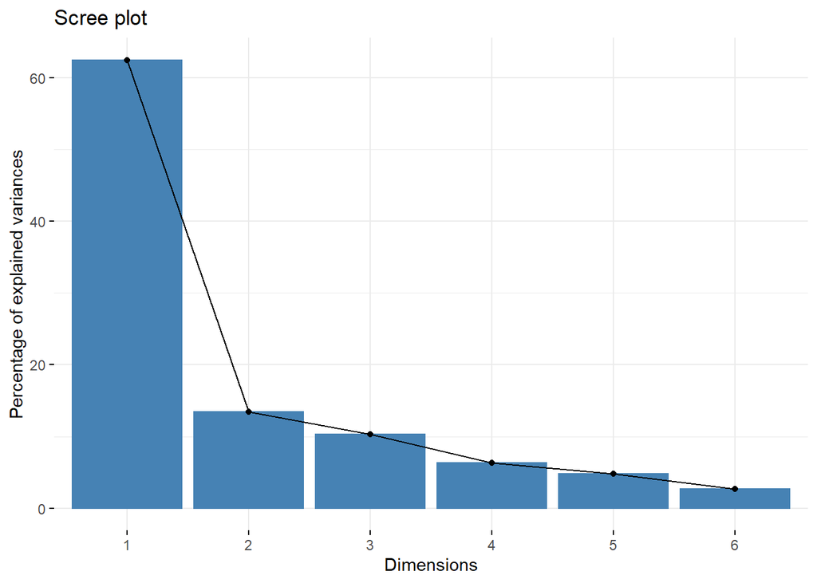

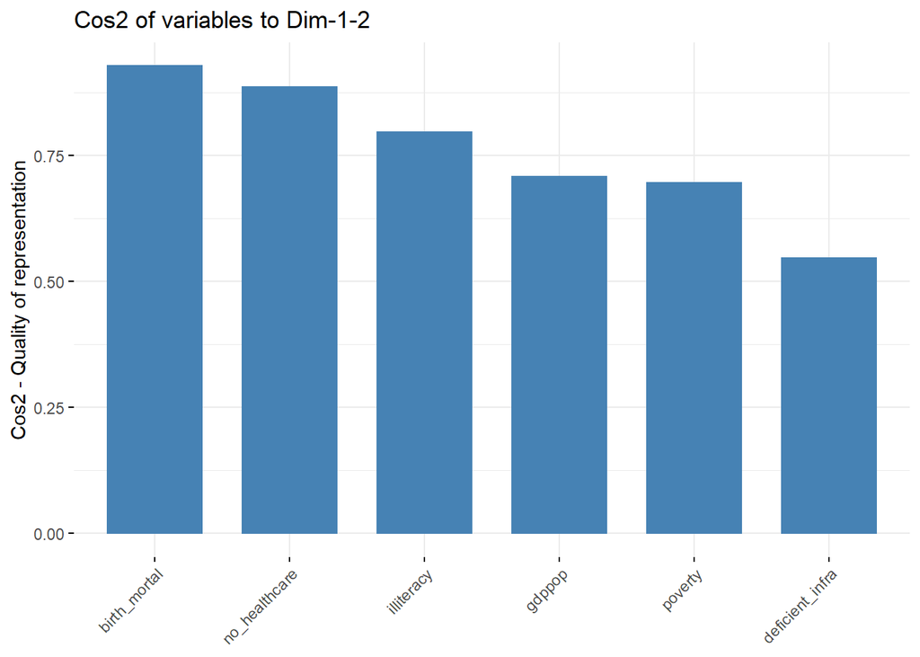

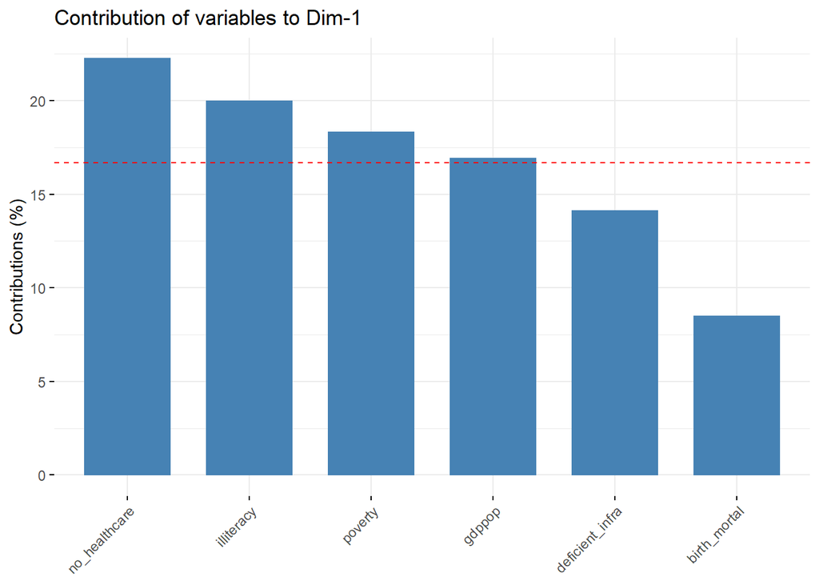

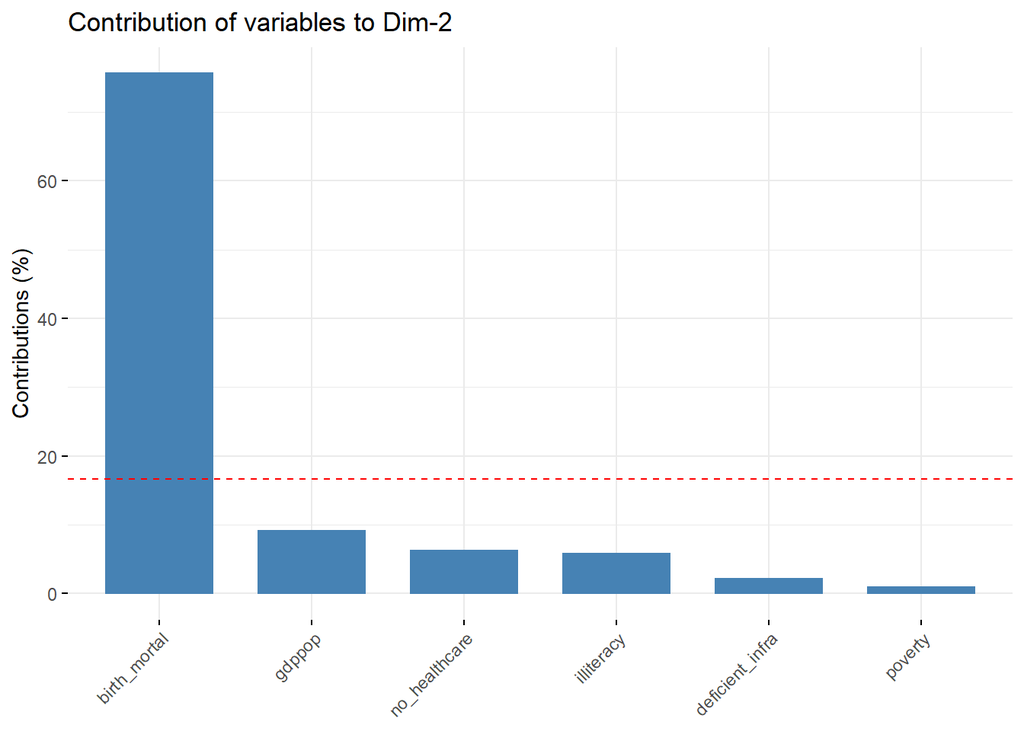

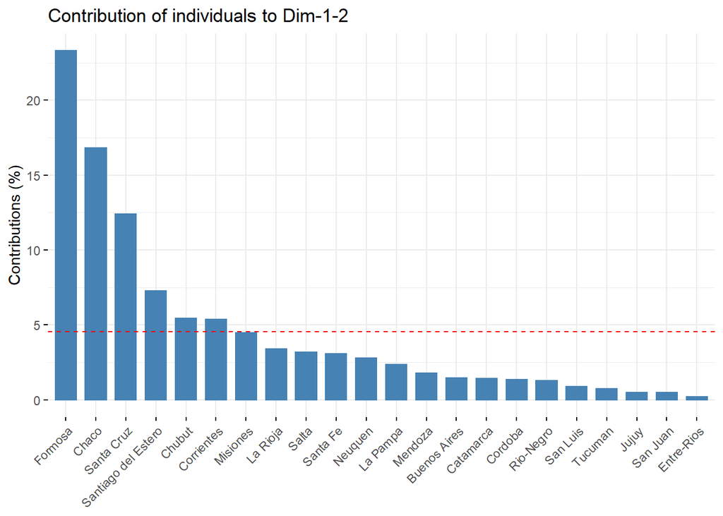

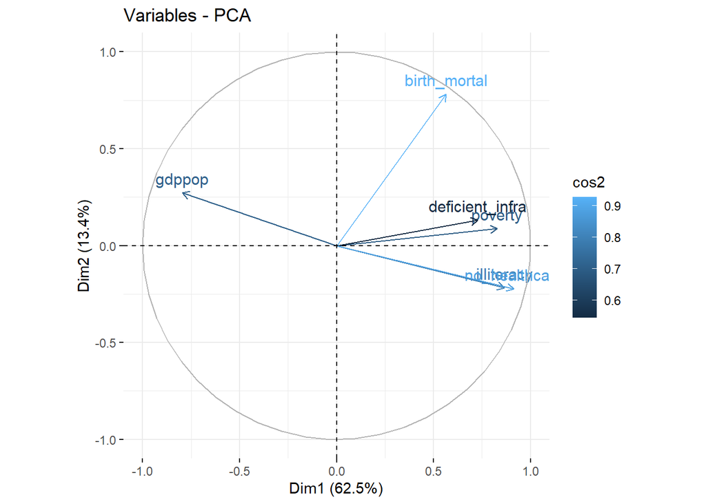

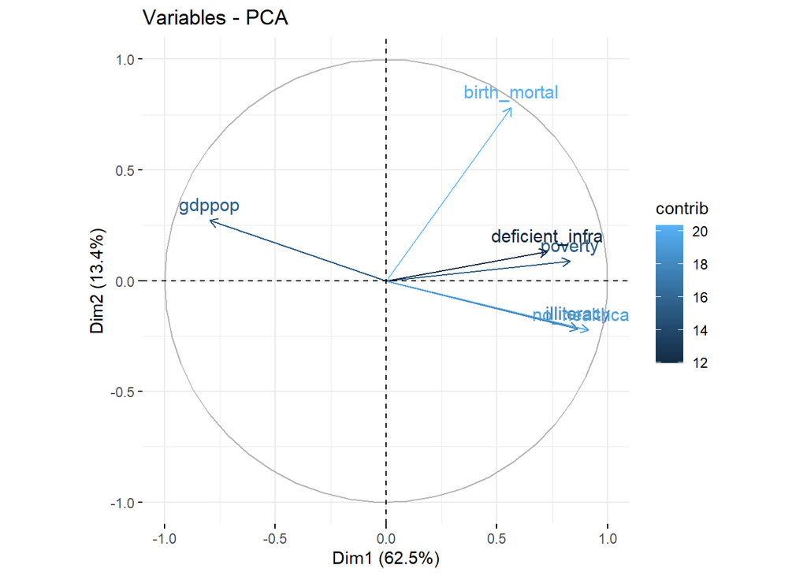

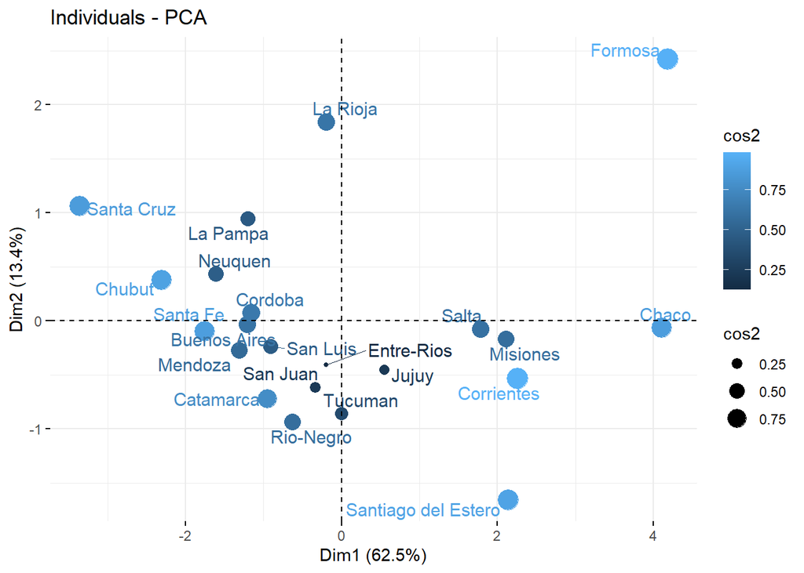

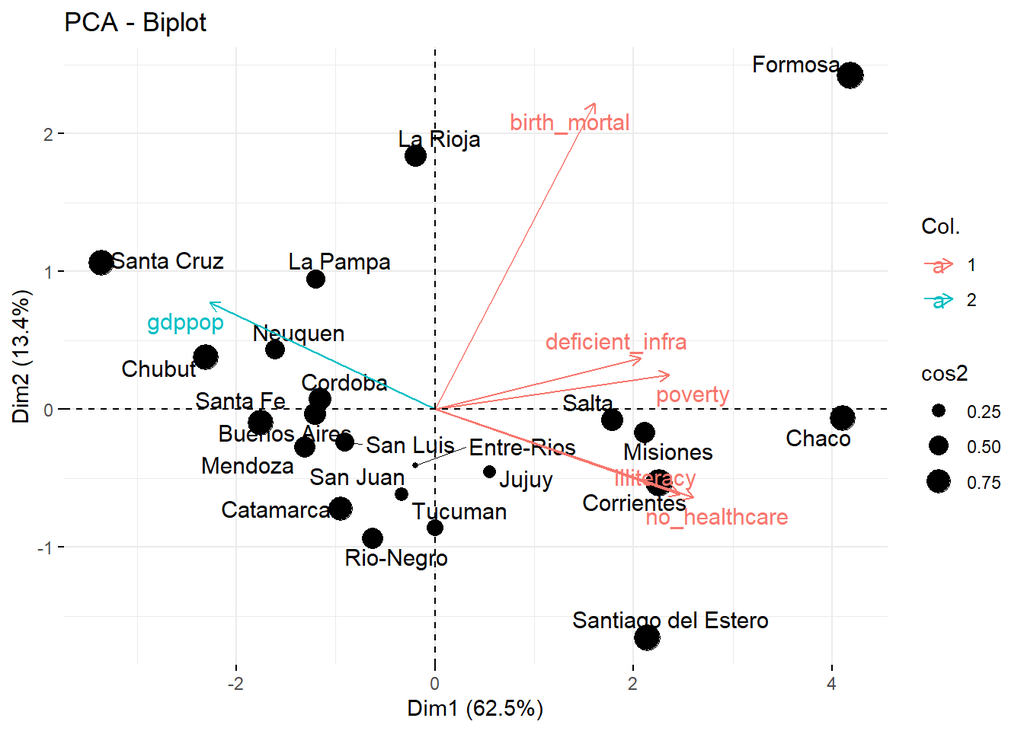

[18 more figures not shown]